# LBD CWOW Brain Single Nucleus Find Markers

Kimberly Olney

06/08/2023

# Set working directory

```r
knitr::opts_knit$set(root.dir = ".")
```

# Libraris, paths, colors

```r
source(here::here("snRNA/scripts/R", "file_paths_and_colours.R"))
tissue <- "Brain"
treatment <- "pilot"
```

# Read in object

```r
# read object
dataObject.unannotated <- readRDS("../../rObjects/brain_unannotated.rds")
```

## Define resolution and groups

```r
# set levels and idents
Idents(dataObject.unannotated) <- "seurat_clusters"
# normalize if SCTtransform was used
DefaultAssay(dataObject.unannotated) <- "RNA"
```

# Clustering QC before annotation

## Unannotated UMAP

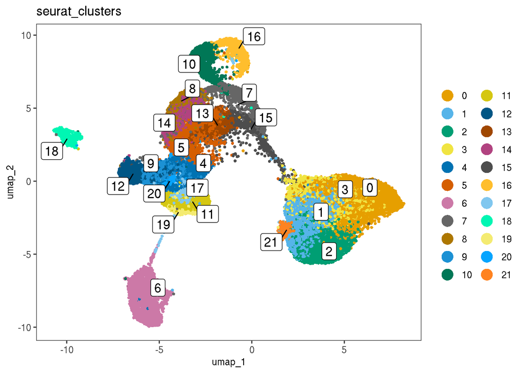

```r
dittoDimPlot(object = dataObject.unannotated,
             var = "seurat_clusters",
             reduction.use = "umap",
             do.label = TRUE,
             labels.highlight = TRUE)
```

## Cells per cluster

```r
dataObject.unannotated$sample <- factor(dataObject.unannotated$sample, levels = c("beads", "debris"))

n_cells <- FetchData(dataObject.unannotated,
  vars = c("ident", "sample")) %>%
  dplyr::count(ident,sample) %>%
  tidyr::spread(ident, n)
n_cells
```

```
##   sample    0    1    2    3    4    5    6    7   8   9  10  11  12  13  14
## 1  beads 3745 3208 2168 1700 1005 1113 1281 1392 843 879 856 685 715 562 532
## 2 debris 3347 2837 1992 1496 1556 1378 1156 1001 996 912 907 813 671 722 665
##    15  16  17  18  19  20  21
## 1 554 365 438 391 235 144 207
## 2 542 713 438 375 250 267 202
```

## Cluster tree

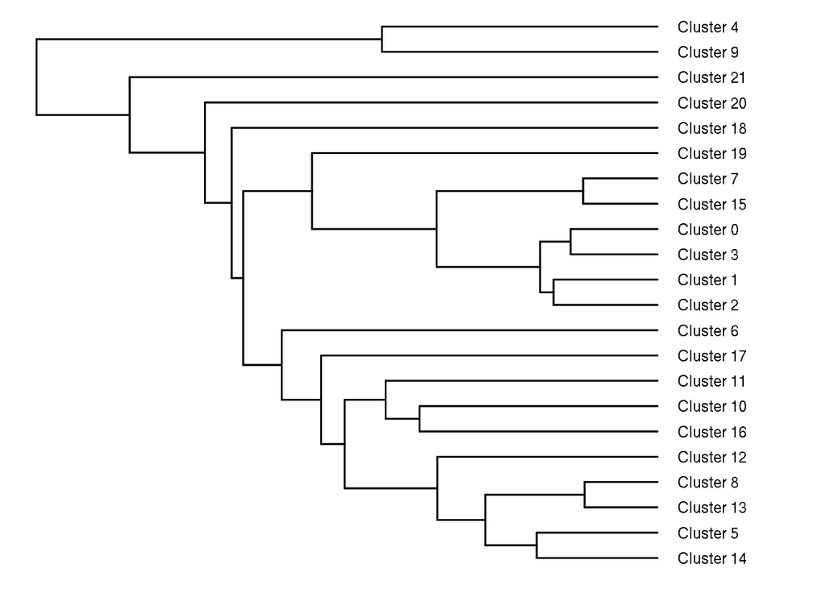

```r
dataObject.unannotated <- BuildClusterTree(object = dataObject.unannotated,
                                     dims = 1:20,
                                     reorder = FALSE,
                                     reorder.numeric = FALSE)

tree <- dataObject.unannotated@tools$BuildClusterTree
tree$tip.label <- paste0("Cluster ", tree$tip.label)

tree_1 <- ggtree::ggtree(tree, aes(x, y)) +
  scale_y_reverse() +
  ggtree::geom_tree() +
  ggtree::theme_tree() +
  ggtree::geom_tiplab(offset = 1) +
#  ggtree::geom_tippoint(color = colors[1:length(tree$tip.label)],
  #                      shape = 16, size = 5) +
  coord_cartesian(clip = 'off') +
  theme(plot.margin = unit(c(0,2.5,0,0), 'cm'))
tree_1
```

# Marker exploration

FindMarkers will find markers between two different identity groups - you have to specify both identity groups. This is useful for comparing the differences between two specific groups.

FindAllMarkers will find markers differentially expressed in each identity group by comparing it to all of the others - you don’t have to manually define anything. Note that markers may bleed over between closely-related groups - they are not forced to be specific to only one group. This is what most people use (and likely what you want).

```r
# read object
all.markers <- readRDS("../../rObjects/unannotated_all_markers.rds")

# more stringent filtering
all.markers <- all.markers[all.markers$p_val_adj < 0.05,]
markers.strict <- all.markers[
  all.markers$delta_pct > summary(all.markers$delta_pct)[5],]

# compare
table(all.markers$cluster)
```

```
##
##    0    1    2    3    4    5    6    7    8    9   10   11   12   13   14   15
## 1052 1056 1068  939 1529 1530 1179 1770 1827 1311 1691 1468 1539 1805 1712 1658
##   16   17   18   19   20   21
## 1417 1350 1531 1364 1176 1272
```

```r
table(markers.strict$cluster)
```

```
##
##    0    1    2    3    4    5    6    7    8    9   10   11   12   13   14   15
##   15    4   35    7  165  956   63   18 1642   62  267  104  734 1678 1448   17
##   16   17   18   19   20   21
##   76   28  335   61   27   68
```

```r
# subset
cluster0 <- markers.strict[markers.strict$cluster == 0,]
cluster1 <- markers.strict[markers.strict$cluster == 1,]
cluster2 <- markers.strict[markers.strict$cluster == 2,]
cluster3 <- markers.strict[markers.strict$cluster == 3,]
cluster4 <- markers.strict[markers.strict$cluster == 4,]
cluster5 <- markers.strict[markers.strict$cluster == 5,]
cluster6 <- markers.strict[markers.strict$cluster == 6,]
cluster7 <- markers.strict[markers.strict$cluster == 7,]
cluster8 <- markers.strict[markers.strict$cluster == 8,]
cluster9 <- markers.strict[markers.strict$cluster == 9,]
cluster10 <- markers.strict[markers.strict$cluster == 10,]
cluster11 <- markers.strict[markers.strict$cluster == 11,]
cluster12 <- markers.strict[markers.strict$cluster == 12,]
cluster13 <- markers.strict[markers.strict$cluster == 13,]
cluster14 <- markers.strict[markers.strict$cluster == 14,]
cluster15 <- markers.strict[markers.strict$cluster == 15,]
cluster16 <- markers.strict[markers.strict$cluster == 16,]
cluster17 <- markers.strict[markers.strict$cluster == 17,]
cluster18 <- markers.strict[markers.strict$cluster == 18,]
cluster19 <- markers.strict[markers.strict$cluster == 19,]
cluster20 <- markers.strict[markers.strict$cluster == 20,]
cluster21 <- markers.strict[markers.strict$cluster == 21,]
```

## Conserved markers

Identify conserved cell type markers To identify canonical cell type marker genes that are conserved across conditions, we provide the FindConservedMarkers() function. This function performs differential gene expression testing for each dataset/group and combines the p-values using meta-analysis methods from the MetaDE R package. For example, we can calculated the genes that are conserved markers irrespective of stimulation condition in cluster 6 (NK cells).

```r
conserved.markers <- readRDS("../../rObjects/brain_conserved_markers.rds")
conserved.markers.strict <- readRDS("../../rObjects/brain_conserved_markers_strict.rds")

# compare
table(conserved.markers$cluster)
```

```
##
##    0    1   10   11   12   13   14   15   16   17   18   19    2   20   21    3
## 1694 1552 3192 2621 3259 4013 3876 2475 1941 1843 2814 1521 1615 1158 1540 1405
##    4    5    6    7    8    9
## 1942 3509 1779 2474 4106 1642
```

```r
table(conserved.markers.strict$cluster)
```

```
##
##    0    1   10   11   12   13   14   15   16   17   18   19    2   20   21    3
##   45   20  499  189 1120 2814 2275   86  116   70  569   89   92   81  113   37
##    4    5    6    7    8    9
##  280 1504  102   67 2722  101
```

```r
conserved.cluster0 <- conserved.markers.strict[conserved.markers.strict$cluster == 0,]
conserved.cluster1 <- conserved.markers.strict[conserved.markers.strict$cluster == 1,]
conserved.cluster2 <- conserved.markers.strict[conserved.markers.strict$cluster == 2,]
conserved.cluster3 <- conserved.markers.strict[conserved.markers.strict$cluster == 3,]
conserved.cluster4 <- conserved.markers.strict[conserved.markers.strict$cluster == 4,]
conserved.cluster5 <- conserved.markers.strict[conserved.markers.strict$cluster == 5,]
conserved.cluster6 <- conserved.markers.strict[conserved.markers.strict$cluster == 6,]
conserved.cluster7 <- conserved.markers.strict[conserved.markers.strict$cluster == 7,]
conserved.cluster8 <- conserved.markers.strict[conserved.markers.strict$cluster == 8,]
conserved.cluster9 <- conserved.markers.strict[conserved.markers.strict$cluster == 9,]
conserved.cluster10 <- conserved.markers.strict[conserved.markers.strict$cluster == 10,]
conserved.cluster11 <- conserved.markers.strict[conserved.markers.strict$cluster == 11,]
conserved.cluster12 <- conserved.markers.strict[conserved.markers.strict$cluster == 12,]
conserved.cluster13 <- conserved.markers.strict[conserved.markers.strict$cluster == 13,]
conserved.cluster14 <- conserved.markers.strict[conserved.markers.strict$cluster == 14,]
conserved.cluster15 <- conserved.markers.strict[conserved.markers.strict$cluster == 15,]
conserved.cluster16 <- conserved.markers.strict[conserved.markers.strict$cluster == 16,]
conserved.cluster17 <- conserved.markers.strict[conserved.markers.strict$cluster == 17,]
conserved.cluster18 <- conserved.markers.strict[conserved.markers.strict$cluster == 18,]
conserved.cluster19 <- conserved.markers.strict[conserved.markers.strict$cluster == 19,]
conserved.cluster20 <- conserved.markers.strict[conserved.markers.strict$cluster == 20,]
conserved.cluster21 <- conserved.markers.strict[conserved.markers.strict$cluster == 21,]
```

## PCs

```r
# Printing out the most variable genes driving PCs
print(x = dataObject.unannotated[["pca"]],
      dims = 1:5,
      nfeatures = 10)
```

```
## PC_ 1
## Positive:  PLP1, MBP, TF, CNP, CTNNA3, ST18, SELENOP, CRYAB, CERCAM, CLDND1
## Negative:  AQP4, SLC1A2, SLC1A3, GFAP, GJA1, F3, CHI3L1, ANGPTL4, DTNA, ATP1A2
## PC_ 2
## Positive:  KCNIP4, MEG3, RP11-909M7.3, RBFOX1, ROBO2, SYT1, CSMD1, SNHG14, OPCML, RALYL
## Negative:  SLC1A3, AQP4, SLC1A2, GJA1, GLUL, GFAP, PLP1, F3, CHI3L1, ANGPTL4
## PC_ 3
## Positive:  VCAN, PTPRZ1, LHFPL3, TNR, PDGFRA, BCAN, GPNMB, PCDH15, GRIK1, CSPG4
## Negative:  NRGN, ENC1, CHN1, SLC17A7, VSNL1, CALM1, CLU, SNAP25, OLFM1, AQP4
## PC_ 4
## Positive:  VCAN, PTPRZ1, GPNMB, BCAN, PDGFRA, TNR, CSPG4, LHFPL3, APOD, COL9A1
## Negative:  CH507-528H12.1, ERBB4, DPP10, CNTNAP2, ROBO2, GRIP1, CH507-513H4.1, RBFOX1, GRIK1, CXCL14
## PC_ 5
## Positive:  CH507-528H12.1, KCNIP4, CH507-513H4.1, PVT1, PCDH9, RALYL, LRP1B, PTPRD, LRRTM4, CSMD1
## Negative:  CXCL14, SLC6A1, GAD2, KIT, GAD1, ERBB4, RELN, GRIK1, GRIP1, DLX6-AS1
```

## Top variable genes

```r
# print top variable genes
top100 <- dataObject.unannotated@assays$SCT@var.features[1:100]
top100
```

```
##   [1] "CXCL14"         "CHI3L1"         "NPY"            "SST"
##   [5] "SLC1A2"         "AQP4"           "GJA1"           "AQP1"
##   [9] "COL19A1"        "PLP1"           "PVT1"           "RELN"
##  [13] "GRIK1"          "SLC1A3"         "VCAN"           "CH507-528H12.1"
##  [17] "GPNMB"          "KIT"            "GFAP"           "ANGPTL4"
##  [21] "PTPRZ1"         "DPP10"          "RP11-986E7.7"   "SERPINA3"
##  [25] "F3"             "ERBB4"          "SGCZ"           "FAM189A2"
##  [29] "BAALC-AS1"      "LHFPL3"         "VIP"            "ROBO2"
##  [33] "KCNIP4"         "GPC5"           "CNR1"           "CH507-513H4.1"
##  [37] "TF"             "RP11-212P7.3"   "DTNA"           "GLUL"
##  [41] "PDGFRA"         "VEGFA"          "MBP"            "ATP1A2"
##  [45] "ADGRV1"         "PCDH9"          "BCAN"           "AEBP1"
##  [49] "SLC14A1"        "TNR"            "CLDN5"          "CALB2"
##  [53] "ZFP36"          "AGT"            "CTD-2126E3.6"   "MT2A"
##  [57] "CTNNA3"         "NXPH1"          "CRH"            "CST3"
##  [61] "SPP1"           "GAD2"           "SLC6A1"         "CD44"
##  [65] "RP1-223B1.1"    "CCK"            "RP11-6L16.1"    "ZNF385D"
##  [69] "RBFOX1"         "ST18"           "CEP162"         "CNP"
##  [73] "RFX4"           "RP11-141F7.1"   "CLU"            "CNTN5"
##  [77] "CNTNAP2"        "ADAMTS9"        "RP4-668E10.4"   "GRIP1"
##  [81] "CSPG4"          "GLIS3"          "ADARB2"         "C4B"
##  [85] "CRYAB"          "APOD"           "C4A"            "FGFR3"
##  [89] "EFEMP1"         "KIAA1217"       "RYR3"           "AC084149.2"
##  [93] "MT1M"           "OBI1-AS1"       "SELENOP"        "SMOC1"
##  [97] "OPALIN"         "CCL2"           "GAD1"           "LINC00609"
```

# Cluster Annotation

## Cluster 0 - oligodendrocyte / polydendrocyte

OPALIN - oligodendrocyte  
MAG - polydendrocyte  
CLDN11 - polydendrocyte / oligodendrocyte  
ANLN - oligodendrocyte  
APOD - fibroblast-like / oligodendrocyte

```r
# Number of cells per condition
n_cells[,c(1,2)]
```

```
##   sample    0
## 1  beads 3745
## 2 debris 3347
```

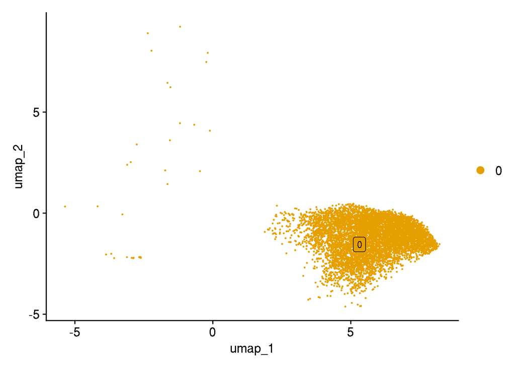

```r
# UMAP with only cluster 0
DimPlot(object = subset(dataObject.unannotated, seurat_clusters == "0"),
        reduction = "umap",
        label = TRUE,
        label.box = TRUE,
        label.size = 3,
        repel = TRUE,
        cols = "#E69F00")
```

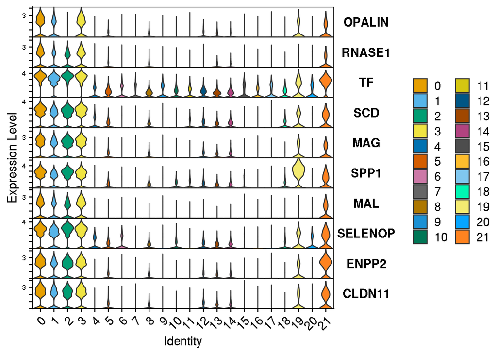

```r
VlnPlot(dataObject.unannotated,
        features = cluster0$gene[1:10],
        cols = colors,
        stack = TRUE,
        flip = TRUE,
        split.by = "seurat_clusters")
```

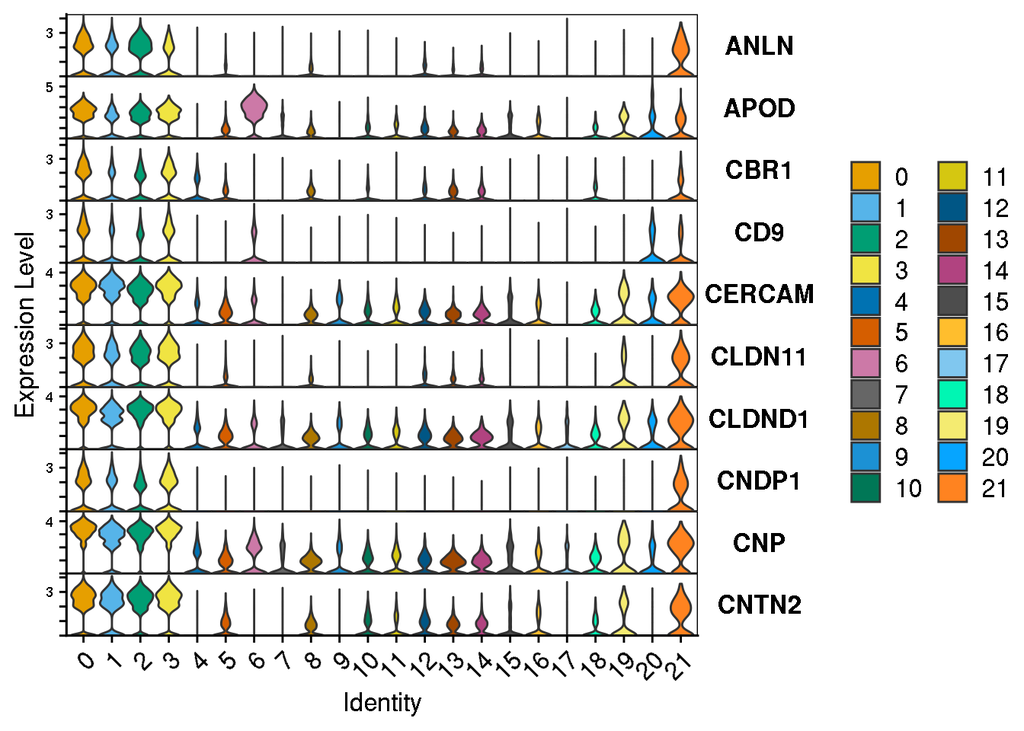

```r
VlnPlot(dataObject.unannotated,
        features = conserved.cluster0$gene[1:10],
        cols = colors,
        stack = TRUE,
        flip = TRUE,
        split.by = "seurat_clusters")
```

```r
cluster0$gene[1:10]
```

```
##  [1] "OPALIN"  "RNASE1"  "TF"      "SCD"     "MAG"     "SPP1"    "MAL"
##  [8] "SELENOP" "ENPP2"   "CLDN11"
```

```r
conserved.cluster0$gene[1:10]
```

```
##  [1] "ANLN"   "APOD"   "CBR1"   "CD9"    "CERCAM" "CLDN11" "CLDND1" "CNDP1"
##  [9] "CNP"    "CNTN2"
```